# replicateBE

Comparative BA-calculation for Average Bioequivalence with Expanding Limits (ABEL)

# Introduction

The package provides datasets (internal `.rda` and in CSV-format in `/extdata/`) which support users in a [black-box](https://en.wikipedia.org/wiki/Black-box_testing) performance qualification (PQ) of their software installations.[^1] Users can analyze data imported from CSV- and Excel-files.

The methods[^2] given by the European Medicines Agency (EMA) for reference-scaling according to the Guideline on the Investigation of Bioequivalence[^3] are implemented. Health Canada’s approach[^4] – requiring a mixed-effects model – is approximated by intra-subject contrasts. Direct widening of the limits for *C*<sub>max</sub> (as a special case of ABEL) recommended by the GCC[^5] is supported as well.

Potential influence of outliers on the variability of the reference can be assessed by box plots of studentized and standardized residuals as suggested at a joint EGA/EMA symposium.[^6]

# Functions

## `method.A()`

A linear model of log-transformed PK responses and effects  
*sequence*, *subject*(*sequence*), *period*, *treatment*  
where all effects are fixed (*i.e.*, evaluated by an ANOVA). Estimated via function `lm()` of package `stats`.

```r
modA <- lm(log(PK) ~ sequence + subject%in%sequence + period + treatment,
                     data = data)
```

## `method.B()`

A linear model of log-transformed PK responses and effects  
*sequence*, *subject*(*sequence*), *period*, *treatment*  
where *subject*(*sequence*) is a random effect and all others are fixed.

Three options are provided

1. Estimated via function `lmer()` of package `lmerTest`.

```r
modB <- lmer(log(PK) ~ sequence + period + treatment + (1|subject),
                       data = data)
```

- Employs Satterthwaite’s approximation[^7] of the degrees of freedom `method.B(..., option = 1)`, which is equivalent to SAS’ `DDFM=SATTERTHWAITE`, Phoenix WinNonlin’s `Degrees of Freedom Satterthwaite`, and Stata’s `dfm=Satterthwaite`.
- Note that this is the only available approximation in SPSS.
2. Estimated via function `lme()` of package `nlme`.

```r
modB <- lme(log(PK) ~ sequence +  period + treatment, random = ~1|subject,
                      data = data)
```

- Employs degrees of freedom equivalent to SAS’ `DDFM=CONTAIN` (implicitly preferred by the EMA), Phoenix WinNonlin’s `Degrees of Freedom Residual`, STATISTICA’s `GLM containment`, and Stata’s `dfm=anova`.
- To comply with the EMA’s Q&A document, `method.B(..., option = 2)` is the default (*i.e.*, if the argument `option` is missing).
3. Estimated via function `lmer()` of package `lmerTest`.

```r
modB <- lmer(log(PK) ~ sequence + period + treatment + (1|subject),
                       data = data)
```

- Employs the Kenward-Roger approximation[^8] of the degrees of freedom `method.B(..., option = 3)`, which is equivalent to Stata’s `dfm=Kenward Roger (EIM)` and SAS’ `DDFM=KENWARDROGER(FIRSTORDER)`, *i.e.*, based on the *expected* information matrix.
- Note that SAS with `DDFM=KENWARDROGER` and JMP calculate Satterthwaite’s [*sic*] degrees of freedom and apply the Kackar-Harville correction[^9] *i.e.*, based on the *observed* information matrix.

## `ABE()`

Average Bioequivalence, where the model is identical to Method A. By default the conventional acceptance range of 80.00 – 125.00% is used. Tighter limits (90.00 – 111.11%) for narrow therapeutic index drugs (EMA and others) or wider limits (75.00 – 133.33% for *C*<sub>max</sub> according to the guideline of South Africa[^10]) can be specified by the arguments `theta1` (lower limit) and/or `theta2` (upper limit).

# Hypotheses

The hypotheses in the confidence interval inclusion approach are
$$\small{H_{0}:
\frac{\mu_\textrm{T}}{\mu_\textrm{R}}\ni
\left\{L,U\right\}\:vs\:H_{1}:L<\frac{\mu_\textrm{T}}{\mu_\textrm{R}}<U}$$
where the null hypothesis is **in**equivalence. In Average Bioequivalence (ABE) the limits $\small{\left\{L,U\right\}}$ are *fixed*, whereas in ABEL they can be *expanded* based on the within-subject variability of the reference treatment.

# Tested designs

Details about the reference datasets and their designs:

```r
help("data", package = "replicateBE")
?replicateBE::data
```

## Four period (full) replicates

Both the test and the reference treatments are administered at least once.

### Two sequences

`TRTR | RTRT`  
`TRRT | RTTR`  
`TTRR | RRTT`

### Four sequences

`TRTR | RTRT | TRRT | RTTR`  
`TRRT | RTTR | TTRR | RRTT`

## Three period (full) replicates

The test treatment is administered at least once to ½ of the subjects and the reference treatment at least once to the respective other ½ of the subjects.

`TRT | RTR`  
`TRR | RTT`

## Two period (full) replicate

The test and reference treatments are administered once to ½ of the subjects (for the estimation of the CI), *i.e.*, the first group of subjects follows a conventional 2×2×2 trial. In the second group the test and reference treatments are administered at least once to ¼ of the subjects, respectively (for the estimation of *CV*<sub>wT</sub> and *CV*<sub>wR</sub>).

`TR | RT | TT | RR`

Although supported, Balaam’s design[^11] is *not recommended* due to its poor power characteristics.

## Three period (partial) replicates

The test treatment is administered once and the reference treatment at least once.

`TRR | RTR | RRT`  
`TRR | RTR`

The latter is the so-called extra-reference design[^12] which is *not recommended* since it is biased in the presence of period effects.

# Data structure

Columns must have the headers `subject`, `period`, `sequence`, `treatment`, `PK`, and/or `logPK`.[^13] Any order of columns is acceptable. Uppercase and mixed case headers will be internally converted to lowercase headers.

## Format

| Variable | Format |
| --- | --- |
| `subject` | Integers or any combination of alphanumeric characters (`A-Z`, `a-z`, `-`, `_`, `#`, `0-9`) |
| `period` | Integers |
| `sequence` | Numbers or literal sequences not listed in the tested designs are not accepted (*e.g.*, **`ABAB`**). |
| `treatment` | The Test treatment must be coded **`T`** and the Reference **`R`** (both uppercase). |
| `PK` | Real positive numbers of PK responses. |
| `logPK` | Real numbers of already log<sub>e</sub>-transformed PK responses (optional and rarely needed). |

Relevant data are used for the estimation of *CV*<sub>wR</sub> (and *CV*<sub>wT</sub> in full replicate designs) and BE, *i.e.*, the datasets might be different (see the example below). It is good practice to state that in the Statistical Analysis Plan.

## Incomplete data

### Estimation of *CV*<sub>w</sub>

If a subject drops out from the study in a higher period, data of repeated administrations will still be used for the estimation of *CV*<sub>w</sub>, although data of the other treatment might be missing. Examples for the estimation of *CV*<sub>wR</sub> (missing values are denoted by `·`):

`RTRT` | `RTR·`  
`TRRT` | `TRR·`  
`RRTT` | `RRT·` or `RR··`  
`RRT` | `RR··`

### Assessment of BE

If a subject drops out from the study in a higher period, data with at least one administration of the Test and Reference will be used in the assessment of BE. Examples (missing values are denoted by `·`):

`TRTR` | `TRT·` or | `TR··`  
`RTRT` | `RTR·` or | `RT··`  
`TRRT` | `TRR·` or | `TR··`  
`RTTR` | `RTT·` or | `RT··`  
`TTRR` | `TTR.`  
`TRT` | `TR·`  
`RTR` | `RT·`  
`TRR` | `TR·`  
`RTR` | `RT·`  
`RTT` | `RT·`

### Example of different datasets

16 subjects enrolled in the study. In sequence `RTRT` one dropout in the 2<sup>nd</sup> period and one in the 4<sup>th</sup> period. In sequence `TRTR` one dropout in the 3<sup>rd</sup> period and one in the 4<sup>th</sup>.

`1 RTR. 5 RTRT 9 TRTR 13 RTRT`  
`2 RTRT 6 TR·· 10 TRTR 14 TRT·`  
`3 RTRT 7 RTRT 11 RTRT 15 TRTR`  
`4 TRTR 8 R··· 12 TRTR 16 TRTR`

We obtain these datasets:

| Dataset | Purpose | included | excluded |
| --- | --- | --- | --- |
| #1 | Estimation of *CV*<sub>wR</sub> | 13 who received 2 treatments `R` | 6, 8, 14 |
| #2 | Assessment of BE | 15 who received ≥1 treatment `T` *and* ≥1 treatment `R` | 8 |
| #3 | Estimation of *CV*<sub>wT</sub> | 13 who received 2 treatments `T` | 1, 6, 8 |

Datasets #1 and #2 are required for ABEL, whereas for ABE only dataset #2 is required.  
Formerly all three were required for the WHO’s reference-scaling of *AUC* (see below).

# Notes on the methods

## Estimation of intra-subject variability

The EMA proposed a linear model of log-transformed PK responses of the reference treatment  
*sequence*, *subject*(*sequence*), *period*  
where all effects are fixed. Estimated via function `lm()` of package `stats`:

```r
modCV <- lm(log(PK) ~ sequence + subject%in%sequence + period,
                      data = data[data$treatment = "R", ])
```

In full replicate designs the same model is run with `data = data[data$treatment = "T", ]` for informational purposes.

Special conditions for the sample size in three period full replicate designs:

> *The question raised asks if it is possible to use a design where subjects are randomised to receive treatments in the order of TRT or RTR.*

> *The CHMP bioequivalence guideline requires that at least 12 patients are needed to provide data for a bioequivalence study to be considered valid, and to estimate all the key parameters. Therefore, if a 3-period replicate design, where treatments are given in the order TRT or RTR, is to be used to justify widening of a confidence interval for C<sub>max</sub> then it is considered that at least 12 patients would need to provide data from the RTR arm. This implies a study with at least 24 patients in total would be required if equal number of subjects are allocated to the 2 treatment sequences.*

> — Q&A document[^14]

If less than twelve subjects are eligible in sequence `RTR` of a `TRT | RTR` design (and in analogy in sequence `TRR` of a `TRR | RTT` design), the user is notified about the ‘uncertain’ estimate of *CV*<sub>wR</sub>. However, in a sufficiently powered study such a case is [extremely unlikely](https://forum.bebac.at/forum_entry.php?id=15139).  
Let us explore the 95% confidence interval of the *CV*:

```r
# Estimate sample sizes of full replicate designs (theta0 0.90,
# target power 0.80) and CI of the CV with package PowerTOST
CV     <- 0.30
design <- c("2x2x4", "2x2x3") # 4- and 3-period full replicate designs
res    <- data.frame(design = rep(design, 2), n = c(rep(NA, 2), rep(12, 2)),
                     df = NA, CV = CV, lower = NA, upper = NA)
# 95% confidence interval of the CV
for (i in 1:nrow(res)) {
  if (is.na(res$n[i])) {
    res$n[i] <- PowerTOST::sampleN.scABEL(CV = CV,
                                          design = res$design[i],
                                          details = FALSE,
                                          print = FALSE)[["Sample size"]]
  }
  if (i > 2 ) {
    n.1 <- res$n[i-2] / 2 # no dropouts in one sequence
    n.2 <- 12             # only 12 eligible subjects in the other
    res$n[i] <- n.1 + n.2
  }
  if (res$design[i] == "2x2x4") {
    res$df[i] <- 3 * res$n[i] - 4
  } else {
    res$df[i] <- 2 * res$n[i] - 3
  }
  res[i, 5:6] <- round(PowerTOST::CVCL(CV = CV,
                                       df = res$df[i],
                                       side = "2-sided",
                                       alpha = 0.05), 3)
}
print(res, row.names = FALSE)
#  design  n df  CV lower upper
#   2x2x4 34 98 0.3 0.262 0.351
#   2x2x3 50 97 0.3 0.262 0.352
#   2x2x4 29 83 0.3 0.259 0.357
#   2x2x3 37 71 0.3 0.256 0.362
# Rows 1-2: Sample sizes for target power
# Rows 3-4: Only 12 eligible subjects in one sequence
```

It is incomprehensible why a four period full replicate design is considered by the EMA to give a more ‘reliable’ estimate of the *CV* than a three period full replicate design.

## Model structure

The EMA’s models assume equal [*sic*] intra-subject variances of Test and Reference (like in 2×2×2 trials) – even if proven false in one of the full replicate designs (were *both* *CV*<sub>wT</sub> and *CV*<sub>wR</sub> can be estimated). Hence, among biostatisticians they are called ‘crippled models’ because the replicative nature of the study is ignored.

```r
library(replicateBE) # attach the library to run example scripts
method.A(data = rds01, print = FALSE, verbose=TRUE)
#
# Data set DS01: Method A by lm()
# ───────────────────────────────────
# Type III Analysis of Variance Table
#
# Response: log(PK)
#                   Df   Sum Sq  Mean Sq  F value     Pr(>F)
# sequence           1   0.0077 0.007652  0.00268  0.9588496
# period             3   0.6984 0.232784  1.45494  0.2278285
# treatment          1   1.7681 1.768098 11.05095  0.0010405
# sequence:subject  75 214.1296 2.855061 17.84467 < 2.22e-16
# Residuals        217  34.7190 0.159995
#
# treatment T – R:
#   Estimate Std. Error    t value   Pr(>|t|)
# 0.14547400 0.04650870 3.12788000 0.00200215
# 217 Degrees of Freedom
```

In ‘Type I’ the *F* value of *sequence* would be $\small{\frac{0.007652}{0.159995}=0.04783}$ with $\small{p(F_{q=0.04783,\,df_1=1,\,df_2=217})\sim 0.827}$, whereas in ‘Type III’ it is $\small{\frac{0.007652}{2.855061}=0.00268}$ with $\small{p(F_{q=0.00268,\,df_1=1,\,df_2=75})\sim 0.959}$.

The nested structure *subject*(*sequence*) of the methods leads to an over-specified model.[^16] The simple model  
*sequence*, *subject*, *period*, *treatment*  
gives identical estimates of the residual variance and the treatment effect and hence, its confidence interval.

The same holds true for the EMA’s model to estimate *CV*<sub>wR</sub>. The simple model  
*subject*, *period*  
gives an identical estimate of the residual variance.

Reference-scaling is acceptable for *C*<sub>max</sub> (immediate release products: BE Guideline) and *C*<sub>max</sub>, *C*<sub>max,ss</sub>, *C*<sub>τ,ss</sub>, <sub>partial</sub>*AUC* (modified release products[^17]). The intention to expand the limits has to be stated in the protocol and – contrary to the FDA’s RSABE – a clinical justification provided.

> *Those HVDP for which a wider difference in C<sub>max</sub> is considered clinically irrelevant based on a sound clinical justification can be assessed with a widened acceptance range. The request for widened interval must be prospectively specified in the protocol.*

> — CHMP Bioequivalence Guideline

## BE limits, PE restriction, rounding issues

The limits can be expanded based on *CV*<sub>wR</sub>.

- $\small{CV_\textrm{wR}\leq 30\%}$  
  Lower cap, *i.e.*, no scaling, conventional limits:  
  $\small{\left\{{L,U}\right\} = 80.00 - 125.00\%}$
- $\small{30\%<CV_\textrm{wR}\leq 50\%}$ (EMA), $\small{30\%<CV_\textrm{wR}\leq \sim57.4\%}$ (Health Canada)  
  Expanded limits based on $s_\textrm{wR}$:  
  $\small{\left\{L,\,U\right\} = 100\cdot \exp(\mp 0.760\cdot{s_\textrm{wR}})}$
- $\small{CV_\textrm{wR}>50\%}$ (EMA), $\small{CV_\textrm{wR}>\sim57.4\%}$  
  Upper cap, *i.e.*, applying $\small{s^*_\textrm{wR}=\sqrt{\log_{e}(CV_\textrm{cap}^{2}+1)}}$ in the expansion formula or  
  $\small{\left\{L,U\right\} = 69.84 - 143.19\%}$ (EMA)  
  $\small{\left\{L,U\right\} = 66.7 - 150.0\%}$ (Health Canada).

The special case recommended by the Gulf Cooperation Council (Bahrain, Kuwait, Oman, Qatar, Saudi Arabia, the United Arab Emirates) is:

- $\small{CV_\textrm{wR}\leq 30\%}$  
  Lower cap, *i.e.*, no scaling, conventional limits:  
  $\small{\left\{{L,U}\right\} = 80.00 - 125.00\%}$
- $\small{CV_\textrm{wR}>30\%}$  
  Widened limits:  
  $\small{\left\{{L,U}\right\} = 75.00 - 133.33\%}$

In reference-scaling a so-called *mixed* (a.k.a. *aggregate*) criterion is applied. In order to pass ABEL,

- the 90% confidence interval has to lie entirely within the acceptance range $\small{\left\{L,U\right\}}$ *and*
- the point estimate (PE) has to lie within 80.00 – 125.00%.

To avoid discontinuities due to double rounding, expanded limits are calculated in full numeric precision and only the confidence interval is rounded according to the guidelines.

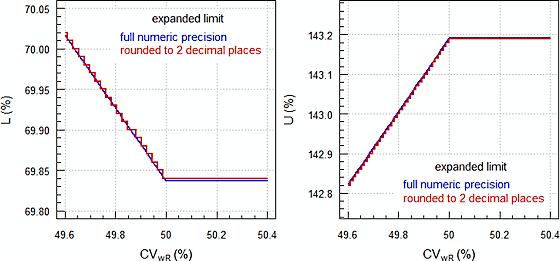

Discrete limits resulting from rounding (EMA)

```r
# Calculate limits with package PowerTOST
CV <- c(30, 50, 57.382)
df <- data.frame(CV = CV,
                 reg1 = "EMA", L1 = NA, U1 = NA, cap1 = "",
                 reg2 = "HC",  L2 = NA, U2 = NA, cap2 = "",
                 reg3 = "GCC", L3 = NA, U3 = NA, cap3 = "",
                 stringsAsFactors = FALSE)
for (i in seq_along(CV)) {
  df[i, 3:4]   <- sprintf("%.3f",
                          PowerTOST::scABEL(CV[i]/100,
                                            regulator = df$reg1[i])*100)
  df[i, 7:8]   <- sprintf("%.1f",
                          PowerTOST::scABEL(CV[i]/100,
                                            regulator = df$reg2[i])*100)
  df[i, 11:12] <- sprintf("%.3f",
                          PowerTOST::scABEL(CV[i]/100,
                                            regulator = df$reg3[i])*100)
}
df$cap3[df$CV <= 30] <- df$cap2[df$CV <= 30] <- df$cap1[df$CV <= 30] <- "lower"
df$cap1[df$CV >= 50 & df$reg1 == "EMA"]    <- "upper"
df$cap2[df$CV >= 57.382 & df$reg2 == "HC"] <- "upper"
names(df) <- c("CV(%)", rep(c("reg", "L(%)", "U(%)", "cap"), 3))
print(df, row.names = FALSE)
#   CV(%) reg   L(%)    U(%)   cap reg L(%)  U(%)   cap reg   L(%)    U(%)   cap
#  30.000 EMA 80.000 125.000 lower  HC 80.0 125.0 lower GCC 80.000 125.000 lower
#  50.000 EMA 69.837 143.191 upper  HC 69.8 143.2       GCC 75.000 133.333
#  57.382 EMA 69.837 143.191 upper  HC 66.7 150.0 upper GCC 75.000 133.333
```